# An Analytical Detective

##### *Unit-1: Introduction to Analytics*

Crime is an international concern, but it is documented and handled in very different ways in different countries. In the United States, violent crimes and property crimes are recorded by the Federal Bureau of Investigation (FBI). Additionally, each city documents crime and some cities release data regarding crime rates. The city of Chicago, Illinois releases crime data from 2001 onward [online](https://goo.gl/N1fQfF).

Chicago is the third most populous city in the United States, with a population of over 2.7 million people.

There are two main types of crimes: violent crimes, and property crimes. In this problem, we’ll focus on one specific type of property crime, called “motor vehicle theft” (sometimes referred to as grand theft auto). This is the act of stealing, or attempting to steal, a car. In this problem, we’ll use some basic data analysis in R to understand the motor vehicle thefts in Chicago.

Please download the file [mvtWeek1.csv](http://bit.ly/2p4175k) for this problem (do not open this file in any spreadsheet software before completing this problem because it might change the format of the Date field). Here is a list of descriptions of variables:

- `ID`: a unique identifier for each observation.
- `Date`: the date the crime occurred.
- `LocationDescription`: the location where the crime occurred.
- `Arrest`: whether or not an arrest was made for the crime (TRUE if an arrest was made, and FALSE if an arrest was not made)
- `Domestic`: whether or not the crime was a domestic crime, meaning that it was committed against a family member (TRUE if it was domestic, and FALSE if it was not domestic)
- `Beat`: the area, or “beat” in which the crime occurred. This is the smallest regional division defined by the Chicago police department.
- `District`: the police district in which the crime occurred. Each district is composed of many beats, and are defined by the Chicago Police Department.
- `CommunityArea`: the community area in which the crime occurred. Since the 1920s, Chicago has been divided into what are called “community areas,” of which there are now 77. The community areas were devised in an attempt to create socially homogeneous regions.
- `Year`: the year in which the crime occurred.
- `Latitude`: the latitude of the location at which the crime occurred.
- `Longitude`: the longitude of the location at which the crime occurred.

#### Loading the Data

Read the dataset [mvtWeek1.csv](http://bit.ly/2p4175k) into R, using the `read.csv` function, and call the data frame “mvt”. Remember to navigate to the directory on your computer containing the file `mvtWeek1.csv` first. It may take a few minutes to read in the data, since it is pretty large. Then, use the `str` and `summary` functions to answer the following questions.

```r
mvt = read.csv("mvtWeek1.csv")
```

##### 1.1 How many rows of data (observations) are in this dataset?

```r
str(mvt)
```

```
## 'data.frame':    191641 obs. of  11 variables:
##  $ ID                 : int  8951354 8951141 8952745 8952223 8951608 8950793 8950760 8951611 8951802 8950706 ...
##  $ Date               : Factor w/ 131680 levels "1/1/01 0:01",..: 42824 42823 42823 42823 42822 42821 42820 42819 42817 42816 ...
##  $ LocationDescription: Factor w/ 78 levels "ABANDONED BUILDING",..: 72 72 62 72 72 72 72 72 72 72 ...
##  $ Arrest             : logi  FALSE FALSE FALSE FALSE FALSE TRUE ...
##  $ Domestic           : logi  FALSE FALSE FALSE FALSE FALSE FALSE ...
##  $ Beat               : int  623 1213 1622 724 211 2521 423 231 1021 1215 ...
##  $ District           : int  6 12 16 7 2 25 4 2 10 12 ...
##  $ CommunityArea      : int  69 24 11 67 35 19 48 40 29 24 ...
##  $ Year               : int  2012 2012 2012 2012 2012 2012 2012 2012 2012 2012 ...
##  $ Latitude           : num  41.8 41.9 42 41.8 41.8 ...
##  $ Longitude          : num  -87.6 -87.7 -87.8 -87.7 -87.6 ...
```

The first row of the output says that there are: 191641 observations.

##### 1.2 How many variables are there in this dataset?

The first row of the `str` output says that there are: 11 variables.

##### 1.3 Using the “max” function, what is the maximum value of the variable “ID”?

```r
max(mvt$ID)
```

```
## [1] 9181151
```

##### 1.4 What is the minimum value of the variable “Beat”?

```r
min(mvt$Beat)
```

```
## [1] 111
```

##### 1.5 How many observations have value TRUE in the Arrest variable (number of crimes for which an arrest was made)?

```r
summary(mvt)
```

```
##        ID                      Date
##  Min.   :1310022   5/16/08 0:00  :    11
##  1st Qu.:2832144   10/17/01 22:00:    10
##  Median :4762956   4/13/04 21:00 :    10
##  Mean   :4968629   9/17/05 22:00 :    10
##  3rd Qu.:7201878   10/12/01 22:00:     9
##  Max.   :9181151   10/13/01 22:00:     9
##                    (Other)       :191582
##                      LocationDescription   Arrest         Domestic
##  STREET                        :156564   Mode :logical   Mode :logical
##  PARKING LOT/GARAGE(NON.RESID.): 14852   FALSE:176105    FALSE:191226
##  OTHER                         :  4573   TRUE :15536     TRUE :415
##  ALLEY                         :  2308
##  GAS STATION                   :  2111
##  DRIVEWAY - RESIDENTIAL        :  1675
##  (Other)                       :  9558
##       Beat         District     CommunityArea        Year
##  Min.   : 111   Min.   : 1.00   Min.   : 0      Min.   :2001
##  1st Qu.: 722   1st Qu.: 6.00   1st Qu.:22      1st Qu.:2003
##  Median :1121   Median :10.00   Median :32      Median :2006
##  Mean   :1259   Mean   :11.82   Mean   :38      Mean   :2006
##  3rd Qu.:1733   3rd Qu.:17.00   3rd Qu.:60      3rd Qu.:2009
##  Max.   :2535   Max.   :31.00   Max.   :77      Max.   :2012
##                 NA's   :43056   NA's   :24616
##     Latitude       Longitude
##  Min.   :41.64   Min.   :-87.93
##  1st Qu.:41.77   1st Qu.:-87.72
##  Median :41.85   Median :-87.68
##  Mean   :41.84   Mean   :-87.68
##  3rd Qu.:41.92   3rd Qu.:-87.64
##  Max.   :42.02   Max.   :-87.52
##  NA's   :2276    NA's   :2276
```

On inspecting the `summary` output, it can be seen that 15,536 observations fall under the category TRUE for the variable Arrest.

##### 1.6 How many observations have value a LocationDescription value of ALLEY?

From the `summary` output, 2308 values fall under the category. Alternatively, `table(mvt$LocationDescription)` can be used.

#### Understanding Dates in R

In many datasets, like this one, you have a date field. Unfortunately, R does not automatically recognize entries that look like dates. We need to use a function in R to extract the date and time. Take a look at the first entry of Date (remember to use square brackets when looking at a certain entry of a variable).

##### 2.1 In what format are the entries in the variable Date?

```r
mvt$Date[1]
```

```
## [1] 12/31/12 23:15
## 131680 Levels: 1/1/01 0:01 1/1/01 0:05 1/1/01 0:30 1/1/01 1:17 ... 9/9/12 9:50
```

The above output suggests that the date format is Month/Day/Year Hour:Minute.

##### 2.2 Converting to Date object.

Now, let’s convert these characters into a Date object in R.

```r
DateConvert = as.Date(strptime(mvt$Date, "%m/%d/%y %H:%M"))
```

This converts the variable “Date” into a Date object in R. Take a look at the variable DateConvert using the summary function.

**What is the month and year of the median date in our dataset?**

```r
summary(DateConvert)
```

```
##         Min.      1st Qu.       Median         Mean      3rd Qu.
## "2001-01-01" "2003-07-10" "2006-05-21" "2006-08-23" "2009-10-24"
##         Max.
## "2012-12-31"
```

The median date is May 2006 (2006-05-21).

##### 2.3 In which month did the fewest motor vehicle thefts occur?

Now, let’s extract the month and the day of the week, and add these variables to our data frame mvt. We can do this with two simple functions. Type the following commands in R:

```r
mvt$Month = months(DateConvert)
mvt$Weekday = weekdays(DateConvert)
```

This creates two new variables in our data frame, Month and Weekday, and sets them equal to the month and weekday values that we can extract from the Date object. Lastly, replace the old Date variable with DateConvert by typing:

```r
mvt$Date = DateConvert
```

*Using the table command, answer the following questions.*

**In which month did the fewest motor vehicle thefts occur?**

```r
sort(table(mvt$Month))
```

```
##
##  February     April     March      June       May   January September
##     13511     15280     15758     16002     16035     16047     16060
##  November  December    August      July   October
##     16063     16426     16572     16801     17086
```

##### 2.4 On which weekday did the most motor vehicle thefts occur?

```r
table(mvt$Weekday)
```

```
##
##    Friday    Monday  Saturday    Sunday  Thursday   Tuesday Wednesday
##     29284     27397     27118     26316     27319     26791     27416
```

##### 2.5 Which month has the largest number of motor vehicle thefts for which an arrest was made?

Each observation in the dataset represent a motor vehicle theft, and the Arrest variable indicates whether an arrest was later made on this theft.

```r
table(mvt$Arrest, mvt$Month)
```

```
##
##         April August December February January  July  June March   May
##   FALSE 14028  15243    15029    12273   14612 15477 14772 14460 14848
##   TRUE   1252   1329     1397     1238    1435  1324  1230  1298  1187
##
##         November October September
##   FALSE    14807   15744     14812
##   TRUE      1256    1342      1248
```

The largest number of observations with Arrest=TRUE are for January.

#### Visualizing Crime Trends

Now, let’s make some plots to help us better understand how crime has changed over time in Chicago. Throughout this problem, and in general, you can save your plot to a file. For more information, [this website](http://bit.ly/2FDcrLQ) very clearly explains the process.

First, let’s make a histogram of the variable Date. We’ll add an extra argument, to specify the number of bars we want in our histogram. In your R console, type

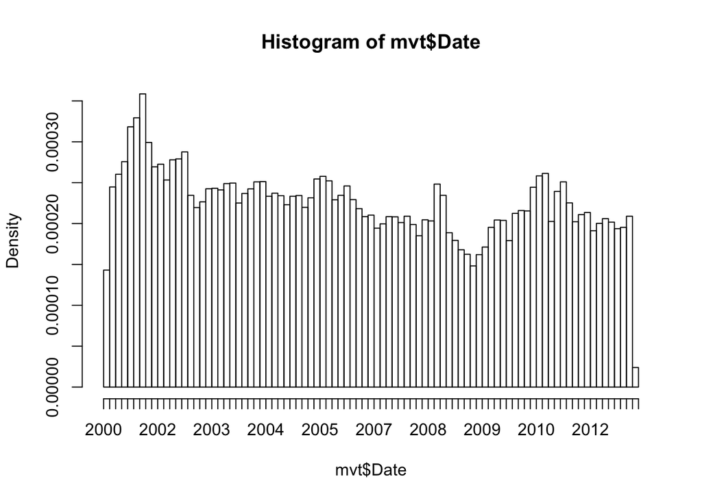

```r
hist(mvt$Date, breaks=100)
```

*Looking at the histogram, answer the following questions.*

**Does it look like the crime increases or decreases from 2002-2012?** Decreases.

**Does it look like the crime increases or decreases from 2005-2008?** Decreases.

**Does it look like the crime increases or decreases from 2009-2011?** Increases.

##### 3.2 Using box-plots

Now, let’s see how arrests have changed over time. Create a boxplot of the variable “Date,” sorted by the variable “Arrest” (if you are not familiar with boxplots and would like to learn more, check out [this tutorial](http://msenux.redwoods.edu/math/R/boxplot.php)). In a boxplot, the bold horizontal line is the median value of the data, the box shows the range of values between the first quartile and third quartile, and the whiskers (the dotted lines extending outside the box) show the minimum and maximum values, excluding any outliers (which are plotted as circles). Outliers are defined by first computing the difference between the first and third quartile values, or the height of the box. This number is called the Inter-Quartile Range (IQR). Any point that is greater than the third quartile plus the IQR or less than the first quartile minus the IQR is considered an outlier.

**Does it look like there were more crimes for which arrests were made in the** **first half of the time period or the second half of the time period?** (Note that the time period is from 2001 to 2012, so the middle of the time period is the beginning of 2007.)

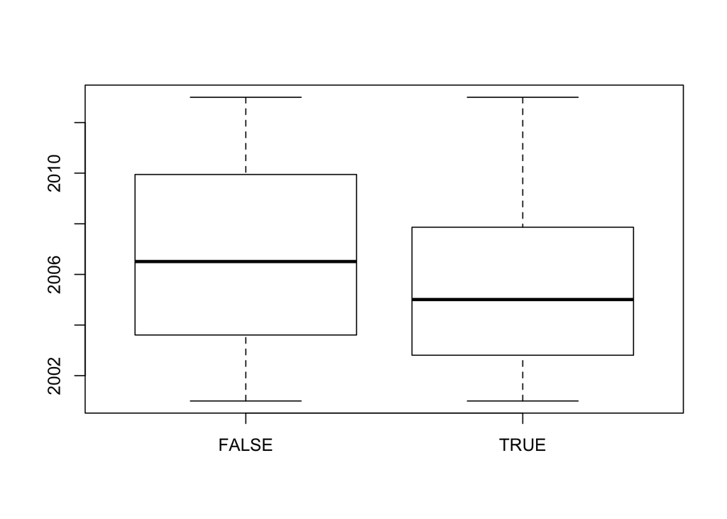

```r
boxplot(mvt$Date ~ mvt$Arrest)
```

From the boxplot, it can be seen that for Arrest=TRUE, it is skewed towards the bottom of the plot, meaning that there were more crimes for which arrests were made in the first half of the time period.

##### 3.3 For what proportion of motor vehicle thefts in 2001 was an arrest made?

Note: in this question and many others in the course, we are asking for an answer as a proportion. Therefore, your answer should take a value between 0 and 1.

```r
table(mvt$Arrest, mvt$Year)
```

```
##
##          2001  2002  2003  2004  2005  2006  2007  2008  2009  2010  2011
##   FALSE 18517 16638 14859 15169 14956 14796 13068 13425 11327 14796 15012
##   TRUE   2152  2115  1798  1693  1528  1302  1212  1020   840   701   625
##
##          2012
##   FALSE 13542
##   TRUE    550
```

##### 3.4 For what proportion of motor vehicle thefts in 2007 was an arrest made?

The required proportion is 1212/(1212+13068) = 0.08487395

##### 3.5 For what proportion of motor vehicle thefts in 2012 was an arrest made?

The required proportion is 550/(550+13542) = 0.03902924

Since there may still be open investigations for recent crimes, this could explain the trend we are seeing in the data. There could also be other factors at play, and this trend should be investigated further. However, since we don’t know when the arrests were actually made, our detective work in this area has reached a dead end.

#### Popular Locations

Analyzing this data could be useful to the Chicago Police Department when deciding where to allocate resources. If they want to increase the number of arrests that are made for motor vehicle thefts, where should they focus their efforts?

We want to find the top five locations where motor vehicle thefts occur. If you create a table of the LocationDescription variable, it is unfortunately very hard to read since there are 78 different locations in the data set. By using the sort function, we can view this same table, but sorted by the number of observations in each category. In your R console, type: `sort(table(mvt$LocationDescription))`

##### 4.1 Which locations are the top five locations for motor vehcle thefts?

```r
sort(table(mvt$LocationDescription), decreasing = TRUE)[1:6]
```

```
##
##                         STREET PARKING LOT/GARAGE(NON.RESID.)
##                         156564                          14852
##                          OTHER                          ALLEY
##                           4573                           2308
##                    GAS STATION         DRIVEWAY - RESIDENTIAL
##                           2111                           1675
```

##### 4.2 Analyse Top-5 Locations

Create a subset of your data, only taking observations for which the theft happened in one of these five locations, and call this new data set “Top5”. To do this, you can use the | symbol. In the lecture, we used the & symbol to use two criteria to make a subset of the data. To only take observations that have a certain value in one variable or the other, the | character can be used in place of the & symbol. This is also called a logical “or” operation.

Alternately, you could create five different subsets, and then merge them together into one data frame using rbind.

**How many observations are in Top5?**

```r
Top5 = subset(mvt, LocationDescription=="STREET" |
                LocationDescription=="PARKING LOT/GARAGE(NON.RESID.)" |
                LocationDescription=="ALLEY" |
                LocationDescription=="GAS STATION" |
                LocationDescription=="DRIVEWAY - RESIDENTIAL")

str(Top5)
```

```
## 'data.frame':    177510 obs. of  13 variables:
##  $ ID                 : int  8951354 8951141 8952223 8951608 8950793 8950760 8951611 8951802 8950706 8951585 ...
##  $ Date               : Date, format: "2012-12-31" "2012-12-31" ...
##  $ LocationDescription: Factor w/ 78 levels "ABANDONED BUILDING",..: 72 72 72 72 72 72 72 72 72 72 ...
##  $ Arrest             : logi  FALSE FALSE FALSE FALSE TRUE FALSE ...
##  $ Domestic           : logi  FALSE FALSE FALSE FALSE FALSE FALSE ...
##  $ Beat               : int  623 1213 724 211 2521 423 231 1021 1215 1011 ...
##  $ District           : int  6 12 7 2 25 4 2 10 12 10 ...
##  $ CommunityArea      : int  69 24 67 35 19 48 40 29 24 29 ...
##  $ Year               : int  2012 2012 2012 2012 2012 2012 2012 2012 2012 2012 ...
##  $ Latitude           : num  41.8 41.9 41.8 41.8 41.9 ...
##  $ Longitude          : num  -87.6 -87.7 -87.7 -87.6 -87.8 ...
##  $ Month              : chr  "December" "December" "December" "December" ...
##  $ Weekday            : chr  "Monday" "Monday" "Monday" "Monday" ...
```

##### 4.3 Which of these locations has a much higher arrest rate than the other locations?

R will remember the other categories of the LocationDescription variable from the original dataset, so running `table(Top5$LocationDescription)` will have a lot of unnecessary output. To make our tables a bit nicer to read, we can refresh this factor variable. In your R console, type:

```r
Top5$LocationDescription = factor(Top5$LocationDescription)
```

If you run the str function again on Top5, you should see that LocationDescription now only has 5 values, as we expect.

Use the Top5 data frame to answer the remaining questions.

```r
table(Top5$LocationDescription, Top5$Arrest)
```

```
##
##                                   FALSE   TRUE
##   ALLEY                            2059    249
##   DRIVEWAY - RESIDENTIAL           1543    132
##   GAS STATION                      1672    439
##   PARKING LOT/GARAGE(NON.RESID.)  13249   1603
##   STREET                         144969  11595
```

On inspecting the percentage of arrests, it is found that *Gas Station* has the highest percentage of arrests, with over *20%* of motor vehicle thefts resulting in an arrest.

##### 4.4 On which day of the week do the most motor vehicle thefts at gas stations happen?

```r
table(Top5$LocationDescription, Top5$Weekday)
```

```
##
##                                  Friday Monday Saturday Sunday Thursday
##   ALLEY                             385    320      341    307      315
##   DRIVEWAY - RESIDENTIAL            257    255      202    221      263
##   GAS STATION                       332    280      338    336      282
##   PARKING LOT/GARAGE(NON.RESID.)   2331   2128     2199   1936     2082
##   STREET                          23773  22305    22175  21756    22296
##
##                                  Tuesday Wednesday
##   ALLEY                              323       317
##   DRIVEWAY - RESIDENTIAL             243       234
##   GAS STATION                        270       273
##   PARKING LOT/GARAGE(NON.RESID.)    2073      2103
##   STREET                           21888     22371
```

Saturday.

##### 4.5 On which day of the week fo the fewest motor vehicle thefts in residential driveways happen?

```r
table(Top5$LocationDescription, Top5$Weekday)
```

```
##
##                                  Friday Monday Saturday Sunday Thursday
##   ALLEY                             385    320      341    307      315
##   DRIVEWAY - RESIDENTIAL            257    255      202    221      263
##   GAS STATION                       332    280      338    336      282
##   PARKING LOT/GARAGE(NON.RESID.)   2331   2128     2199   1936     2082
##   STREET                          23773  22305    22175  21756    22296
##
##                                  Tuesday Wednesday
##   ALLEY                              323       317
##   DRIVEWAY - RESIDENTIAL             243       234
##   GAS STATION                        270       273
##   PARKING LOT/GARAGE(NON.RESID.)    2073      2103
##   STREET                           21888     22371
```

Saturday.

*End of Homework Assignment*